# Practice 7.6

# Visualization

## Load the required libraries

```r
library(xUCINET)
library(statnet)
```

## Removing nodes with specific characteristics

- How to remove specific nodes from a network (as in Figures 7.21 and 7.22)

To focus on nodes with specific characteristics, we might want to remove other nodes.

For example, we could remove all isolates, or remove all nodes with a certain characteristic, such as gender = male.

To illustrate the effect, we will first draw the collaboration network among all 504 scientists. We draw the network ties representing collaboration higher than 6.

Let’s start by drawing the whole network, and keep the coordinates to compare the effect when specific groups of actors are removed.

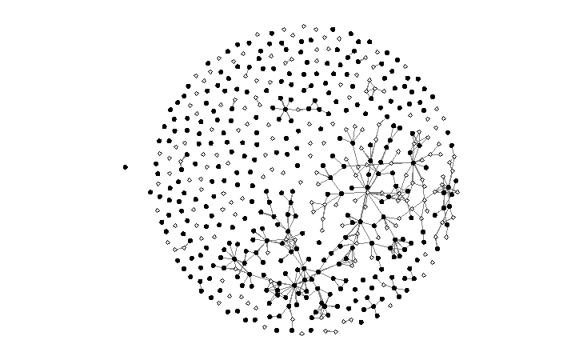

```r
par(mar = c(0, 0, 0, 0))
BS504CCOOR<-gplot(Borgatti_Scientists504$Collaboration>6,
                  gmode="graph",
                  edge.lwd=.6,
                  edge.col="grey50",
                  vertex.sides = (Borgatti_Scientists504$Attributes$Sex-1)*47+4,
                  vertex.col=Borgatti_Scientists504$Attributes$Sex-1)
```

The *gplot* function has a specific argument to remove isolates.

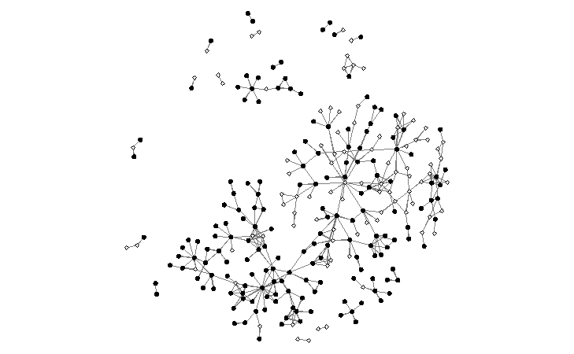

```r
par(mar = c(0, 0, 0, 0))
gplot(Borgatti_Scientists504$Collaboration>6,
      coord=BS504CCOOR,
      gmode="graph",
      edge.lwd=.6,
      edge.col="grey50",
      vertex.sides=(Borgatti_Scientists504$Attributes$Sex-1)*47+4,
      vertex.col=Borgatti_Scientists504$Attributes$Sex-1,
      displayisolates=FALSE)
```

Next we remove nodes based on gender. To extract part of a matrix, we need the vector with attributes **Borgatti_Scientists504$Attributes$Sex**.

```r
Borgatti_Scientists504$Collaboration_F<-Borgatti_Scientists504$Collaboration[Borgatti_Scientists504$Attributes$Sex==1,Borgatti_Scientists504$Attributes$Sex==1]
dim(Borgatti_Scientists504$Collaboration_F)
```

```
[1] 177 177
```

We also need to remove select part of the vector with coordinates.

```r
BS504CCOOR_F<-BS504CCOOR[Borgatti_Scientists504$Attributes$Sex==1,]
dim(BS504CCOOR_F)
```

```
[1] 177   2
```

We can now draw the network for this group:

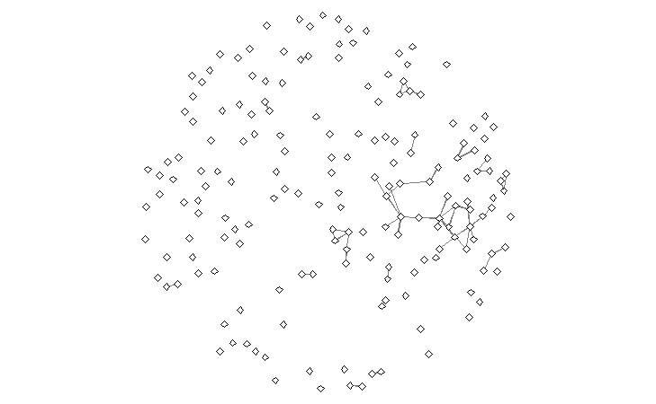

```r
par(mar = c(0, 0, 0, 0))
gplot(Borgatti_Scientists504$Collaboration_F>6,
      coord=BS504CCOOR_F,
      gmode="graph",
      edge.lwd=.6,
      edge.col="grey50",
      vertex.sides=4,
      vertex.col="white")
```

As we can see, only ties among women remain, as removing the male nodes also removed all their ties.

To remove the women, we follow a similar process:

```r
Borgatti_Scientists504$Collaboration_M<-Borgatti_Scientists504$Collaboration[Borgatti_Scientists504$Attributes$Sex==2,Borgatti_Scientists504$Attributes$Sex==2]
dim(Borgatti_Scientists504$Collaboration_M)
```

```
[1] 327 327
```

```r
BS504CCOOR_M<-BS504CCOOR[Borgatti_Scientists504$Attributes$Sex==2,]
dim(BS504CCOOR_M)
```

```
[1] 327   2
```

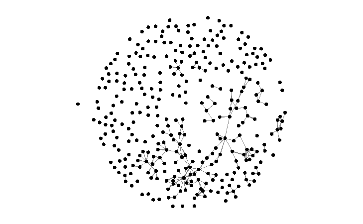

```r
par(mar = c(0, 0, 0, 0))
gplot(Borgatti_Scientists504$Collaboration_M>6,
      coord=BS504CCOOR_M,
      gmode="graph",
      edge.lwd=.6,
      edge.col="grey50",
      vertex.sides=51,
      vertex.col="black")
```

## Extracting the egonetwork

- How to create ego-network drawings from a complete network (as for the scientist in Figures 7.23)

There are two ways to draw an ego-network:

- one involves drawing the network of ego and alters
- the second involves only drawing the alters of an ego and removing ego (as ego will always have a tie to all alters by default).

The choice is partly dependent on whether there is other information about the relation between ego an alter (the strength of the relation, other types of ties or ego-alter similarity) that might be relevant.

As an illustration, let’s consider the egonetwork of node 10 in the collaboration network among 504 scientists. Here we only consider alters who have a tie strength of 6 or more. The alters can be identified by taking the 10th row.

```r
EGO<-10
BS504C_Ego10Sel<-Borgatti_Scientists504$Collaboration[EGO,]>5
```

```r
BS504C_Ego10Sel[EGO]<-1
```

Now we can select only those nodes from the matrix who are alters of node 10:

```r
BS504C_Ego10MAT<-Borgatti_Scientists504$Collaboration[BS504C_Ego10Sel==1,BS504C_Ego10Sel==1]
BS504C_Ego10MAT
```

```
      A1038 H6501 J0347 L5257 Q3226 Z0090
A1038    29     6     6     6     8     6
H6501     6    40     0     7     0     0
J0347     6     0    32     4     1    11
L5257     6     7     4    39     2     3
Q3226     8     0     1     2    70     1
Z0090     6     0    11     3     1    59
```

And the attributes of node 10’s alters:

```r
BS504C_Ego10ATTR<-Borgatti_Scientists504$Attributes[BS504C_Ego10Sel==1,]
```

To ensure only the ties of strength higher than 5, and to rescale the weights so that 6 becomes 1, 7 becomes 2, etc:

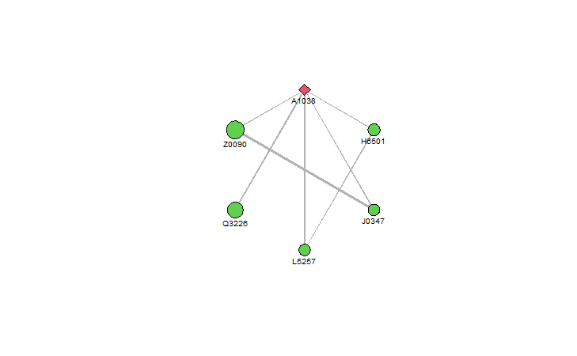

```r
gplot((BS504C_Ego10MAT-5)*(BS504C_Ego10MAT>5),
      gmode="graph",
      mode="circle",
      displaylabels=TRUE,
      vertex.cex=BS504C_Ego10ATTR$Years/15+1,
      edge.lwd=.6,
      edge.col="grey70",
      vertex.col = BS504C_Ego10ATTR$Sex+1,
      vertex.sides = (BS504C_Ego10ATTR$Sex-1)*47+4, jitter=F,
      label.cex=.6,
      label.pos=1)
```